# Assignment-1

## DSC 478 | Programming Machine Learning Applications | Spring 2026

#### Assignment-1 | Avni Sanghvi

```python
import pandas as pd
import matplotlib.pyplot as plt
import seaborn as sns
import numpy as np
```

[output not shown]

### 1. Download the data set adult-modified-04-06-2026 and load it into an appropriate data structure such as a Pandas dataframe. Explore the general characteristics of the data as a whole: examine the means, standard deviations, and other statistics associated with the numeric attributes and frequencies associated with categorical attributes.

```python
# Creating a data frame with dataset
adult = pd.read_csv("adult-modified-04-06-2026.csv")
adult.head()
```

|  | age | workclass | education | education-num | marital-status | occupation | relationship | race | sex | hours-per-week | native-country | income |
| --- | --- | --- | --- | --- | --- | --- | --- | --- | --- | --- | --- | --- |
| 0 | ? | Private | 11th | 7 | Married | Transport-moving | Husband | White | Male | 40 | United-States | <=50K |
| 1 | 59 | Private | HS-grad | 9 | Divorced | Tech-support | Unmarried | White | Female | 40 | United-States | <=50K |
| 2 | 56 | Public | Bachelors | 13 | Married | Tech-support | Husband | White | Male | 40 | United-States | >50K |
| 3 | 19 | Private | HS-grad | 9 | Never-married | Craft-repair | Own-child | White | Male | 40 | United-States | <=50K |
| 4 | 54 | ? | Some-college | 10 | Married | ? | Husband | Asian-Pac-Islander | Male | 60 | South | >50K |

#### Data Exploration

```python
# size of the data
adult.shape
```

```
(31757, 12)
```

```python
# columns present in the dataset
adult.columns
```

```
Index(['age', 'workclass', 'education', 'education-num', 'marital-status',
       'occupation', 'relationship', 'race', 'sex', 'hours-per-week',
       'native-country', 'income'],
      dtype='str')
```

```python
# data type of each columns
adult.dtypes
```

```
age                 str
workclass           str
education           str
education-num     int64
marital-status      str
occupation          str
relationship        str
race                str
sex                 str
hours-per-week    int64
native-country      str
income              str
dtype: object
```

```python
# changing the data type of age from str to int. It is not asked to do in the assignment, but this would be needed to work in Q3.
adult['age'] = pd.to_numeric(adult['age'], errors = 'coerce')

# verifying the change
adult['age'].dtypes
```

```
dtype('float64')
```

```python
# changing the data type of all str type columns to type category
categorical = ["workclass", "education", "marital-status", "occupation", "relationship", "race", "sex",
               "native-country", "income"]

for col in categorical:
    adult[col] = adult[col].astype('category')

# verifying the change
adult.dtypes
```

```
age                float64
workclass         category
education         category
education-num        int64
marital-status    category
occupation        category
relationship      category
race              category
sex               category
hours-per-week       int64
native-country    category
income            category
dtype: object
```

```python
# statistical information of numeric columns
adult.describe()
```

|  | age | education-num | hours-per-week |
| --- | --- | --- | --- |
| count | 31715.000000 | 31757.000000 | 31757.000000 |
| mean | 38.568721 | 10.079762 | 40.425418 |
| std | 13.649368 | 2.569741 | 12.331916 |
| min | 17.000000 | 1.000000 | 1.000000 |
| 25% | 28.000000 | 9.000000 | 40.000000 |
| 50% | 37.000000 | 10.000000 | 40.000000 |
| 75% | 48.000000 | 12.000000 | 45.000000 |
| max | 90.000000 | 16.000000 | 99.000000 |

```python
# correlation between numerical columns
adult[ ["age", "education-num", "hours-per-week"] ].corr()
```

|  | age | education-num | hours-per-week |
| --- | --- | --- | --- |
| age | 1.000000 | 0.038367 | 0.069734 |
| education-num | 0.038367 | 1.000000 | 0.148393 |
| hours-per-week | 0.069734 | 0.148393 | 1.000000 |

```python
# to keep the plots in the notebook
%matplotlib inline
```

#### Examine the frequencies of values in categorical columns

```python
adult.describe(include=['category'])
```

|  | workclass | education | marital-status | occupation | relationship | race | sex | native-country | income |
| --- | --- | --- | --- | --- | --- | --- | --- | --- | --- |
| count | 31757 | 31757 | 31757 | 31757 | 31757 | 31757 | 31757 | 31757 | 31757 |
| unique | 6 | 16 | 7 | 15 | 6 | 5 | 2 | 42 | 2 |
| top | Private | HS-grad | Married | Prof-specialty | Husband | White | Male | United-States | <=50K |
| freq | 22122 | 10250 | 14619 | 4036 | 12864 | 27142 | 21263 | 28459 | 24121 |

```python
for cat in categorical:
    print(cat + " counts:",adult[cat].value_counts())
```

```
workclass counts: workclass
Private          22122
Public            4244
Self-employed     3571
?                 1802
Without-pay         13
Never-worked         5
Name: count, dtype: int64
education counts: education
HS-grad         10250
Some-college     7118
Bachelors        5227
Masters          1672
Assoc-voc        1347
11th             1150
Assoc-acdm       1041
10th              914
7th-8th           629
Prof-school       558
9th               496
12th              417
Doctorate         401
5th-6th           326
1st-4th           164
Preschool          47
Name: count, dtype: int64
marital-status counts: marital-status
Married                  14619
Never-married            10443
Divorced                  4330
Separated                  991
Widowed                    965
Married-spouse-absent      408
?                            1
Name: count, dtype: int64
occupation counts: occupation
Prof-specialty       4036
Craft-repair         3985
Exec-managerial      3953
Adm-clerical         3676
```

[output cut: 64 more lines]

```
Cambodia                         18
Hong                             18
Laos                             18
Thailand                         18
Yugoslavia                       16
Outlying-US(Guam-USVI-etc)       14
Hungary                          13
Honduras                         12
Scotland                         11
Holand-Netherlands                1
Name: count, dtype: int64
income counts: income
<=50K    24121
>50K      7636
Name: count, dtype: int64
```

```python
# to catch the missing values
adult.replace(r'^\s*\?\s*$', np.nan, regex=True, inplace=True)
```

[output not shown]

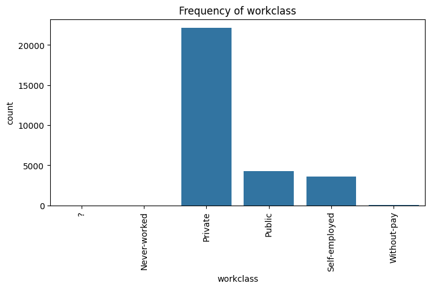

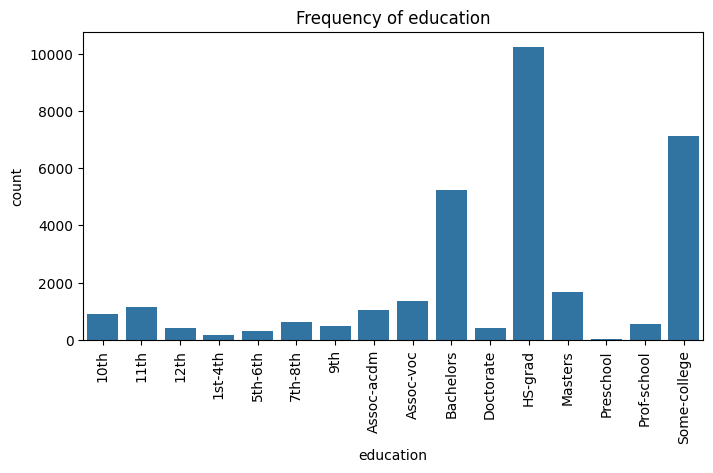

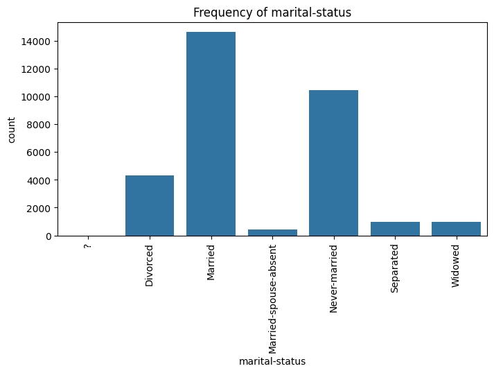

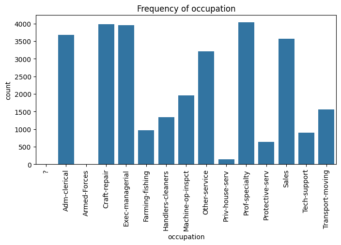

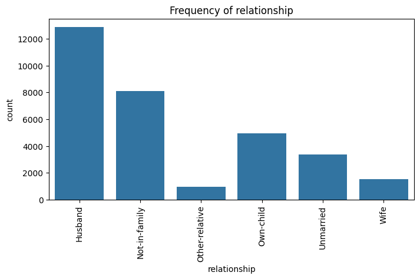

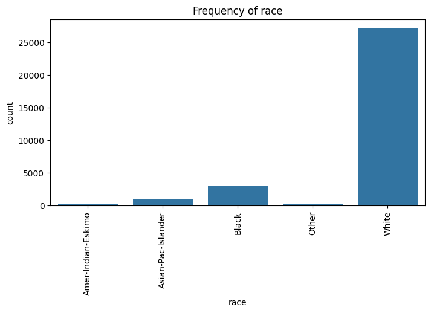

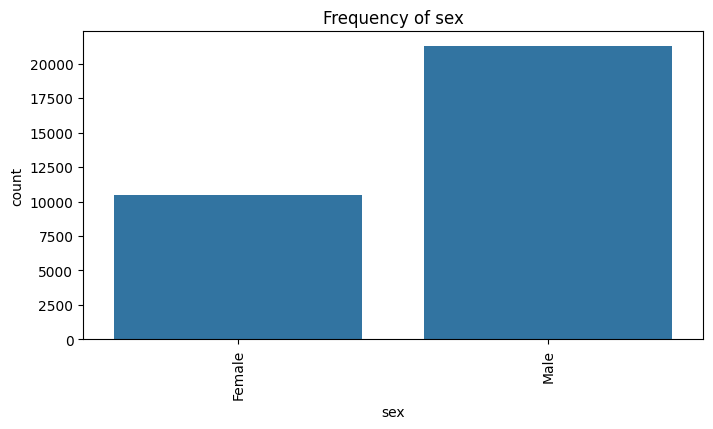

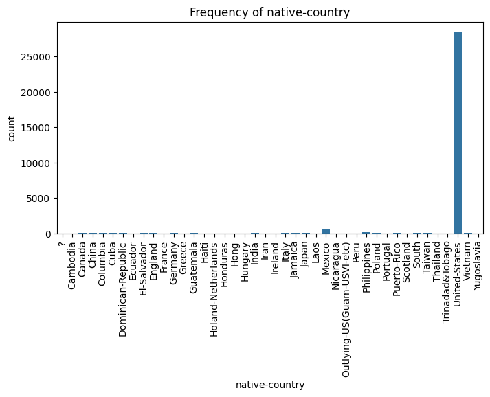

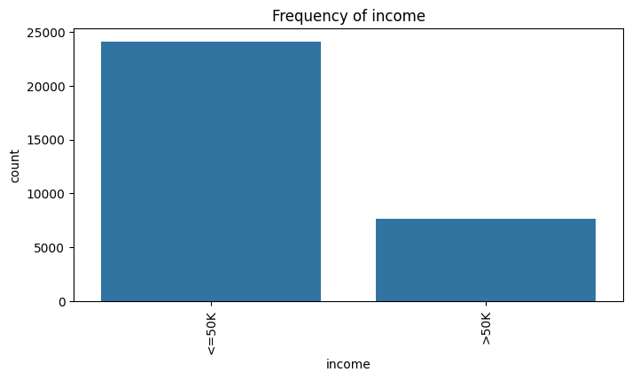

```python
# count plot for each categorical variable

for col in categorical:
    plt.figure(figsize=(8,4))
    sns.countplot(data=adult,x=col)
    plt.title(f'Frequency of {col}')
    plt.xticks(rotation=90)
    plt.show()
```

### 2. Using Pandas, compute the number of missing values for each attribute in the data. Fill the missing values for all numeric attributes using the mean value for the attribute. After filling in the missing numeric values, drop all rows where a categorical attribute contains a missing value. Next, remove columns education and native-country. Show that the final resulting dataframe does not contain missing values and display the new mean and standard deviations for the numeric attributes. For the remaining parts of this assignment, you should use this new dataframe without missing values and the aforementioned columns.

#### Missing values check

```python
adult.isnull().sum()
```

```
age                 42
workclass         1802
education            0
education-num        0
marital-status       1
occupation        1807
relationship         0
race                 0
sex                  0
hours-per-week       0
native-country     561
income               0
dtype: int64
```

```python
# handling missing values of numerical column 'age'
age_mean = adult['age'].mean()
adult['age'] = adult['age'].fillna(age_mean)
```

```python
# verifying missing values for 'age' column
adult.isnull().sum()
```

```
age                  0
workclass         1802
education            0
education-num        0
marital-status       1
occupation        1807
relationship         0
race                 0
sex                  0
hours-per-week       0
native-country     561
income               0
dtype: int64
```

```python
# dropping rows with missing values in categorical attributes
adult.dropna(subset = ['workclass', 'occupation', 'native-country', 'marital-status' ], inplace = True)
```

```python
adult['workclass'].value_counts()
```

```
workclass
Private          21726
Public            4181
Self-employed     3494
Without-pay         13
?                    0
Never-worked         0
Name: count, dtype: int64
```

```python
# drop columns 'education' and 'native-country'
adult.drop("education", axis = 1, inplace = True)
adult.drop("native-country", axis = 1, inplace = True)
```

```python
# check for missing values
adult.isnull().sum()
```

```
age               0
workclass         0
education-num     0
marital-status    0
occupation        0
relationship      0
race              0
sex               0
hours-per-week    0
income            0
dtype: int64
```

```python
# statiscal decription of remaining columns
adult.describe()
```

|  | age | education-num | hours-per-week |
| --- | --- | --- | --- |
| count | 29414.000000 | 29414.000000 | 29414.000000 |
| mean | 38.426052 | 10.120317 | 40.927416 |
| std | 13.132056 | 2.546899 | 11.967882 |
| min | 17.000000 | 1.000000 | 1.000000 |
| 25% | 28.000000 | 9.000000 | 40.000000 |
| 50% | 37.000000 | 10.000000 | 40.000000 |
| 75% | 47.000000 | 13.000000 | 45.000000 |
| max | 90.000000 | 16.000000 | 99.000000 |

### 3. For the three numeric attributes (age, hours-per-week, education-num), display box plots that show the overall dispersion and skew in these variables. Next, create histograms for these three variables showing the overall data distribution in each. Finally, display a scatter plot of age (x-axis) vs. education-num (y-axis).

#### Box plots for numerical variables

```
[]
```

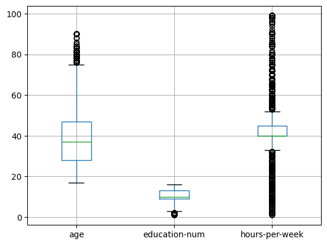

```python
adult.boxplot(column = ["age", "education-num", "hours-per-week"], return_type='axes')
plt.plot()
```

#### Histograms for all three variables

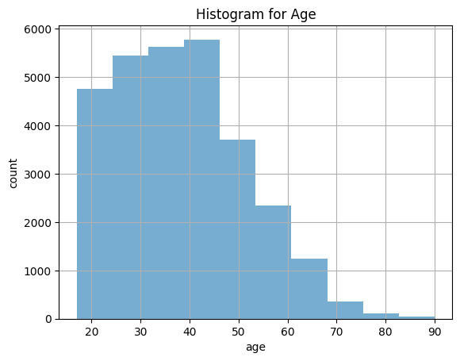

```python
# age attribute
plt.hist(adult['age'], alpha = 0.6)
plt.xlabel('age')
plt.ylabel('count')
plt.title('Histogram for Age')
plt.grid(True)
```

The skewness of data is observed with this plot. The data is right-skewed.

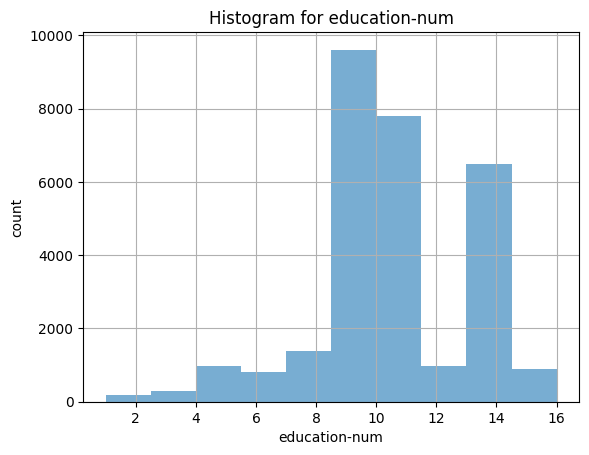

```python
# education-num attribute
plt.hist(adult['education-num'], alpha = 0.6)
plt.xlabel('education-num')
plt.ylabel('count')
plt.title('Histogram for education-num')
plt.grid(True)
```

The skewness of data is also observed in this feature. The data is left-skewed.

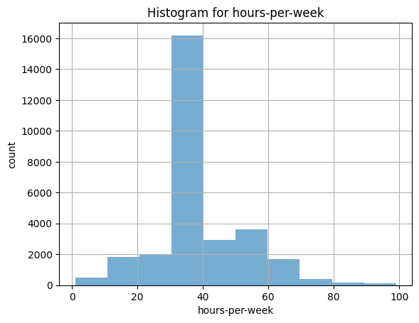

```python
# hours-per-week attribute
plt.hist(adult['hours-per-week'], alpha = 0.6)
plt.xlabel('hours-per-week')
plt.ylabel('count')
plt.title('Histogram for hours-per-week')
plt.grid(True)
```

'hours-per-week' is less skewed than the other two. A little right-skewness is observed in this feature.

#### Scatter plot - age vs education-num

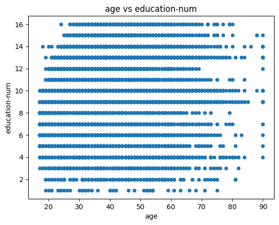

```python
adult.plot(x="age",y="education-num",kind="scatter" )
plt.title("age vs education-num")
```

The strip pattern is seen because we are plotting a numerical column(age) with a oridinal variable(education-num). Even though, we can see various people of all ages have a education but we cannot find any conclusion or pattern with it.

### 4. Create bar charts for all the categorical attributes in the data that show the distribution of category frequencies (e.g., Male vs. Female for the sex attribute, Private vs. Public vs. Self-emp, etc. for the workclass attribute, and so on).

#### Male vs Female

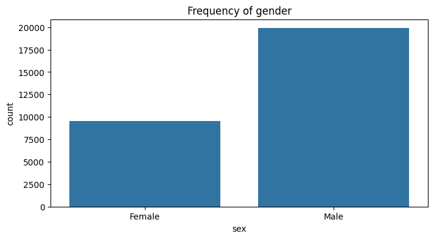

```python
plt.figure(figsize=(8,4))
sns.countplot(data=adult,x="sex")
plt.title(f'Frequency of gender')
plt.show()
```

There is a high imbalance between both the genders.

Male are nearly double than females.

#### Distribution of workclass

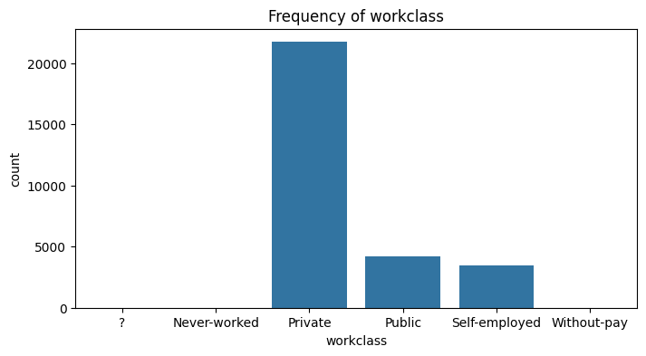

```python
plt.figure(figsize=(8,4))
sns.countplot(data=adult,x="workclass")
plt.title(f'Frequency of workclass')
plt.show()
```

The maximum of adults are employed in a private sector.

The people working in public or are self employed are very few as compared to ones in private sectors.

There is a very small difference in counts of people working in public sector and people who are self-employed.

#### Distribution of marital-status

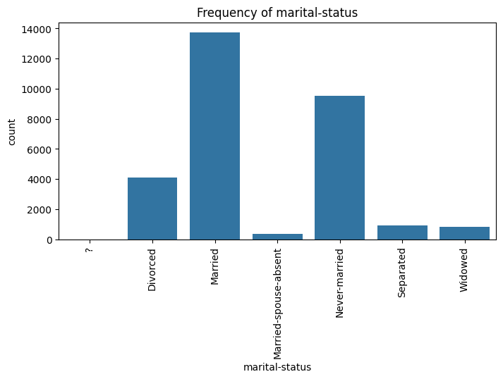

```python
plt.figure(figsize=(8,4))
sns.countplot(data=adult,x="marital-status")
plt.title(f'Frequency of marital-status')
plt.xticks(rotation=90)
plt.show()
```

This feature holds a diversified values.

Maximum people are married, with a count of arounf 13k.

Next, higher proportion are of never-married population, which is roughly around 10k.

Around 4k people are divorced.

A very few proportion of around 1k each of separated and widowed.

A small percentage is also seen for people who are married but their spouse are absent.

#### Occupation distribution

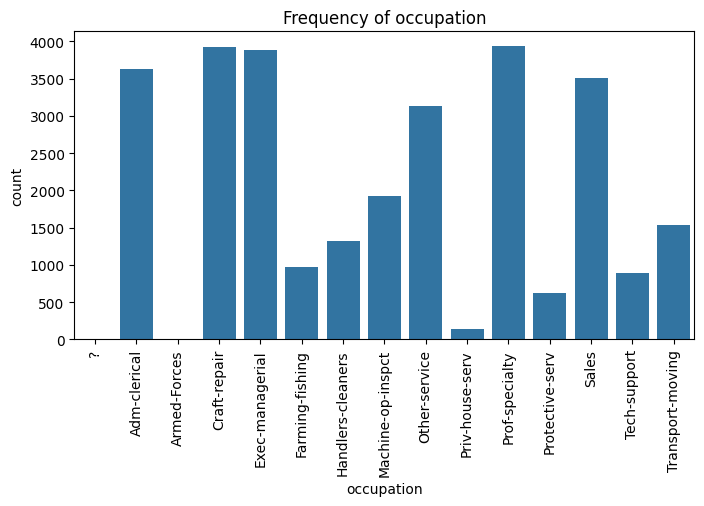

```python
plt.figure(figsize=(8,4))
sns.countplot(data=adult,x="occupation")
plt.title(f'Frequency of occupation')
plt.xticks(rotation=90)
plt.show()
```

This is a more diversed attribute than marital-status.

The most popular occupations are craft-repair, exec-managerial, prof-speciality, sales and adm-clerical.

For arounf 3k people, we do not have the exact occupation of people.

A very few people are employed in private house service.

Machine opertion inspect is also observed but not very popular.

Farming-fishing is something chosen less than others.

#### Relationship distribution

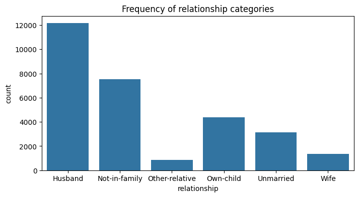

```python
plt.figure(figsize=(8,4))
sns.countplot(data=adult,x="relationship")
plt.title(f'Frequency of relationship categories')
plt.show()
```

'Husband' is the most relationship role found in the data. This makes sense with the class imbalance of genders wtith male in higher numbers.

There are many adults also who are not in a family, about 7800.

About 3k are unmarried, which matches with the earlier observation.

#### Race distribution

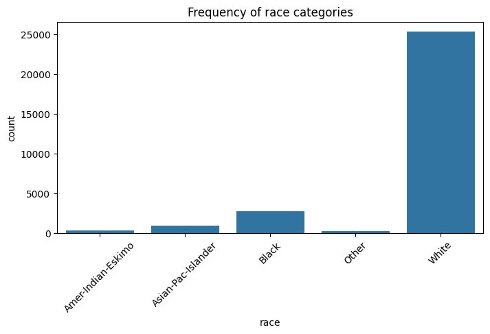

```python
plt.figure(figsize=(8,4))
sns.countplot(data=adult,x="race")
plt.title(f'Frequency of race categories')
plt.xticks(rotation=45)
plt.show()
```

There is a major class imbalance of data in this feature.

25k people are white and about 2.5k are black.

Rest of the races are in very small percentages.

#### Income distribution

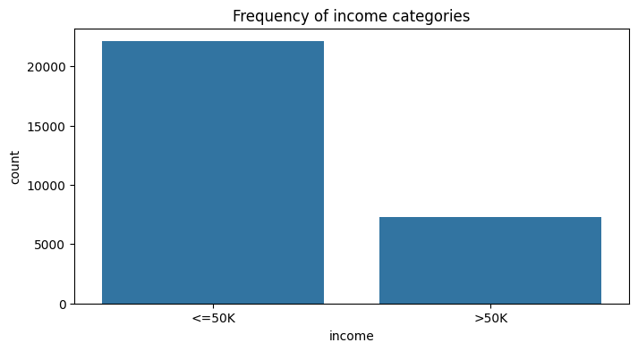

```python
plt.figure(figsize=(8,4))
sns.countplot(data=adult,x="income")
plt.title(f'Frequency of income categories')
plt.show()
```

A high class imbalance is seen in this feature also.

Majority of people, more than 22k people, are earning less than 50k a month.

### 5. Perform a two cross-tabulations: one for the race attribute with the income attribute and one for the race attribute with the education-num attribute. Show the resulting cross-tab tables as well as bar charts to visualize the relationships between these pairs of attributes. [Hint: you can use aggregation functions in Pandas such as cross-tab(), then either using Matplotlib directly or the plot() function in Pandas create the bar charts]. As an illustration, consider this example graph depicting the cross-tabulation of sex with income (Note: this example is based on a different data set, so yours will be different). In the case of race vs. income cross-tab, create another chart comparing the percentages of each race category that fall in the low-income group.

#### cross-tabulation of race with income attribute

```python
race_income = pd.crosstab(adult["race"], adult["income"])
race_income
```

| income race | <=50K | >50K |
| --- | --- | --- |
| Amer-Indian-Eskimo | 247 | 33 |
| Asian-Pac-Islander | 634 | 239 |
| Black | 2382 | 360 |
| Other | 204 | 21 |
| White | 18635 | 6659 |

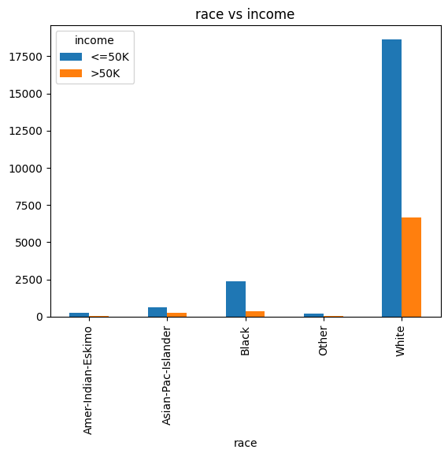

```python
# visulaizing the race with income
plt.show(race_income.plot(kind="bar", title = "race vs income"))
```

For all races, majority of people are earning less than 50k month.

#### cross tab for comparing the percentages of each race category that falls in the low-income group.

```python
race_income_pct = pd.crosstab(adult["race"], adult["income"], normalize='index').round(2)
race_income_pct
```

| income race | <=50K | >50K |
| --- | --- | --- |
| Amer-Indian-Eskimo | 0.88 | 0.12 |
| Asian-Pac-Islander | 0.73 | 0.27 |
| Black | 0.87 | 0.13 |
| Other | 0.91 | 0.09 |
| White | 0.74 | 0.26 |

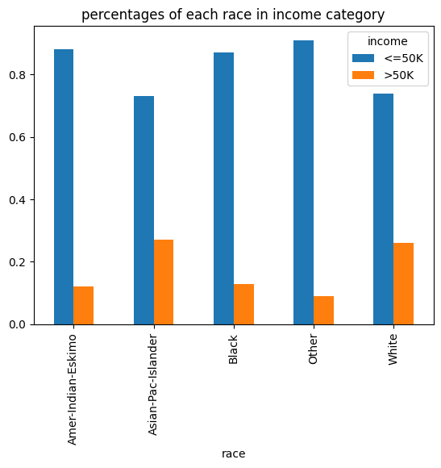

```python
# visulaizing the race with income
plt.show(race_income_pct.plot(kind="bar", title = "percentages of each race in income category"))
```